# Quality control of a genetic map

Noëlle Schenk

June 28, 2018

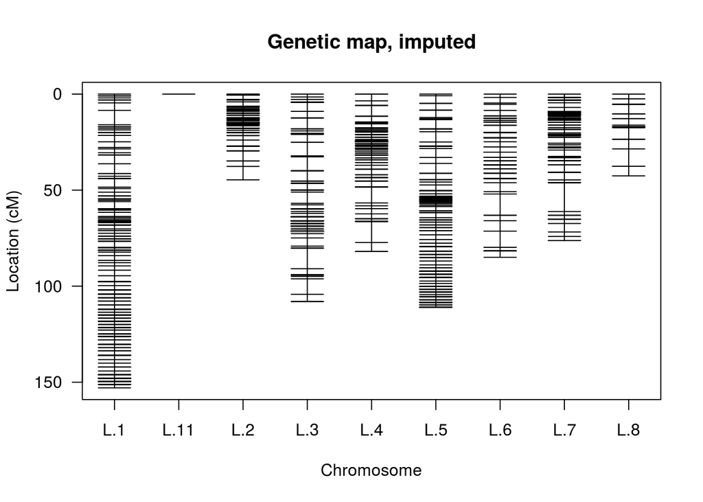

```r
require(ASMap)
require(RColorBrewer)
require(dplyr)
require(ggplot2)
require(reshape2)
require(ggparallel)
require(wgaim)
require(VennDiagram)
setwd("/home/exserta/Documents/master_project_noelle/projects/BioNano-exserta/GBS_LepMAP3")
dopdf = TRUE # to create pdf document
# read in data
map1 <- readRDS("map1_imputed.rds")
plot.map(map1, main = "Genetic map, imputed")
```

```r
summaryMap(map1)
```

```
##         n.mar length ave.spacing max.spacing
## L.1       393  152.9         0.4         7.5
## L.11        1    0.0          NA          NA
## L.2       231   44.6         0.2         7.0
## L.3       260  108.0         0.4        10.8
## L.4       206   81.9         0.4        11.0
## L.5       343  111.0         0.3         5.4
## L.6       157   85.0         0.5        11.1
## L.7       234   76.3         0.3        15.1
## L.8        27   42.6         1.6         9.0
## overall  1852  702.3         0.4        15.1
```

## Crossovers

TODO : does that look strange? Shouldn’t that be around 50 and even up to 200?

```r
# print number of crossovers of all individuals per chromosome
XOs <- countXO(map1, bychr=T)
# get mena number of XOs per chromosome
apply(XOs, 2, mean)
```

```
##       L.1      L.11       L.2       L.3       L.4       L.5       L.6
## 2.2879581 0.0000000 0.7172775 1.7486911 1.2670157 1.7382199 1.0314136
##       L.7       L.8
## 1.1151832 1.8638743
```

```r
# get overall mean of XOs over all linkage groups
mean(countXO(map1))
```

```
## [1] 11.76963
```

## Heat map

Lower triangle : pairwise LOD scores, higher triangle : pairwise estimated RFs. Heat of lower triangle should match heat of upper triangle. Markers within linkage groups are consistent linkage. The linkage within groups is much higher than linkage between groups. A clear clustering was possible.

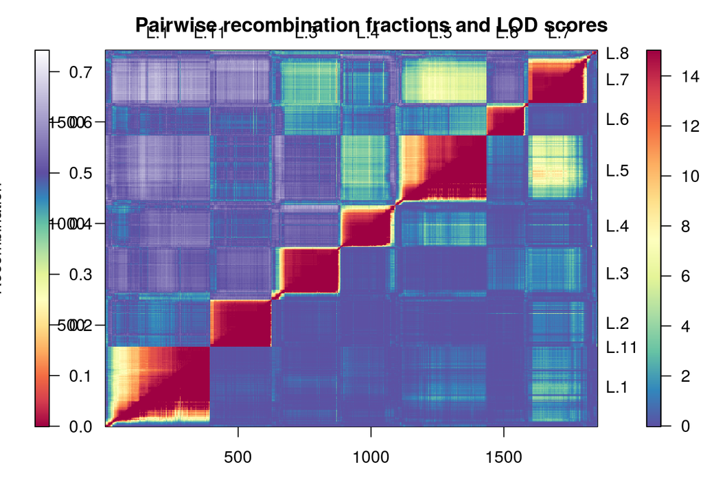

```r
heatMap(map1, lmax=15)
```

## Check recombination rate

The recombination rate should be appropriate, this is one of the key quality characteristics.

If there are Genotypes that exceed this expected recombination rate, they are shown in the graph below. xo.lambda: Number of crossovers is minimum 1 per generation and chromosome. Can be up to around 4.

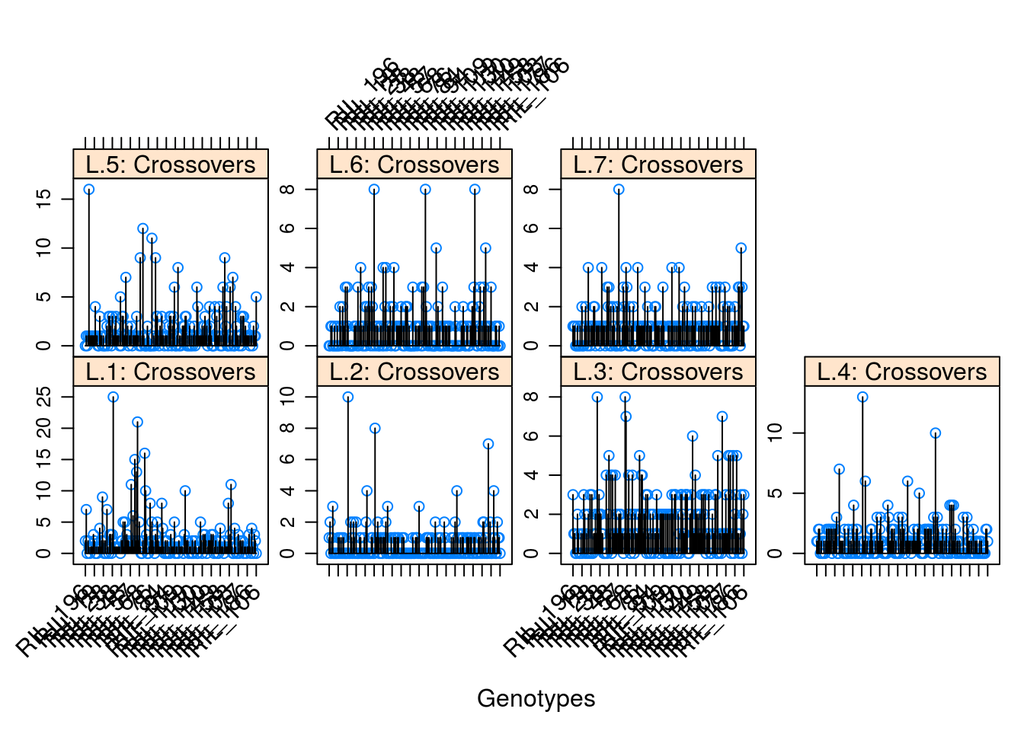

```r
# for(i in paste("L.", seq(1,7), sep="")){
#   profileGen(map1, stat.type = c("xo", "dxo", "miss"), xo.lambda = 7, chr=i)
# }
# pdf("profileGen.pdf")
profileGen(map1, stat.type = "xo", xo.lambda = 49, chr=paste("L.", seq(1,7), sep=""))
```

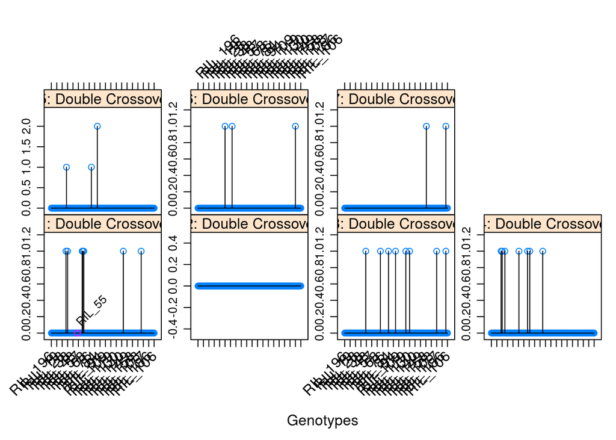

```r
profileGen(map1, stat.type = "dxo", xo.lambda = 49, chr=paste("L.", seq(1,7), sep=""))
```

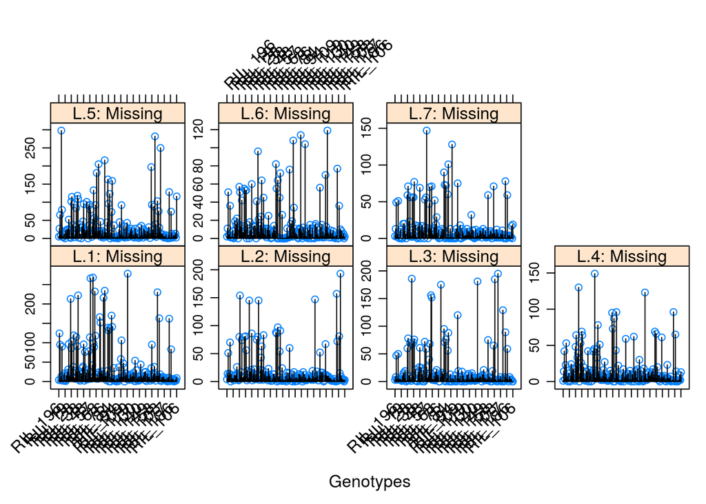

```r
profileGen(map1, stat.type = "miss", chr=paste("L.", seq(1,7), sep=""))
```

```r
# dev.off()
```

## profile mark

profile individual marker and interval statistics.

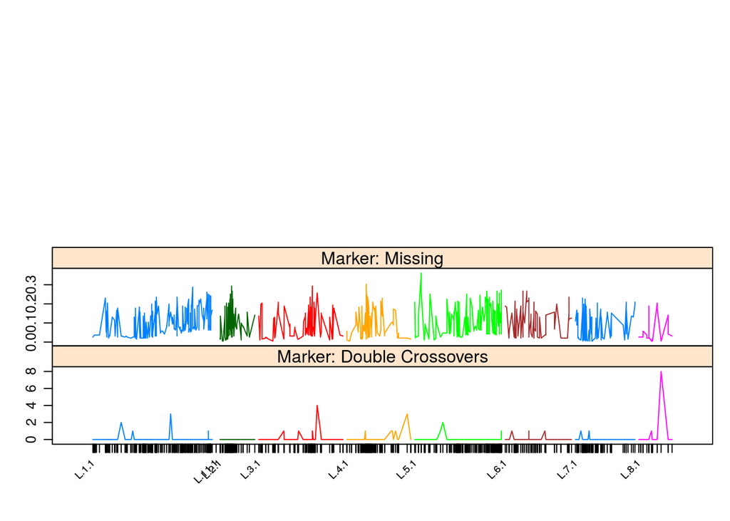

```r
#profileMark(map1, stat.type = c("miss", "recomb", "dxo"), id = "Genotype", layout = c(1, 4), type = "l")
profileMark(map1, stat.type = c("miss", "dxo"), id = "Genotype", layout = c(1, 4), type = "l")
```

## Genotypes

```r
# map1 <- readRDS("map1_imputed.rds")
#map1$geno$L.1$data
# exf <- vector()
# for(i in 1:ncol(map1$geno$L.7$data)){
#   ax <- table(map1$geno$L.7$data[,i])[[1]]
#   ex <- table(map1$geno$L.7$data[,i])[[2]]
#   exf[i] <- ex / (ax+ex)
# }
# exf7 <- exf
# tosave <- c(1, exf1,2,  exf2, 3,  exf3,4,  exf4,5,  exf5,6,  exf6,7, exf7)
# saveRDS(tosave, "exfrequencies.rds")

# load the saved vectors of frequency
tosave <- readRDS("exfrequencies.rds")
exf1 <- tosave[2:(which(tosave == 2)-1)] ; exf2 <- tosave[(which(tosave == 2)+1):(which(tosave == 3)-1)] ; exf3 <- tosave[(which(tosave == 3)+1):(which(tosave == 4)-1)] ; exf4 <- tosave[(which(tosave == 4)+1):(which(tosave == 5)-1)] ; exf5 <- tosave[(which(tosave == 5)+1):(which(tosave == 6)-1)] ; exf6 <- tosave[(which(tosave == 6)+1):(which(tosave == 7)-1)] ; exf7 <- tosave[(which(tosave == 7)+1):length(tosave)]

exf_vecs <- c(paste("exf", seq(1,7), sep=""))
exf_names <- c(paste("L", seq(1,7), sep="."))
# plot
#par(mfrow = c(2, 4))
for(i in 1:7){
  a <- get(exf_vecs[i])
  plot(a, ylim=c(0,1), main=exf_names[i], axes = F, xlab="markers", ylab="") ; lines(a, lty=1); abline(h=0.5, col="red"); axis(side=1)
  abline(h=1, col="lightgray", lty=2) ; abline(h=0, col="lightgray", lty=2)
}
#dev.off()
```

[output not shown]

Show frequency of genotypes along the map, this also shows linkage disequilibrium.

## create pdf of graphs

```r
if(dopdf == T){
  pdf("figures/QC_map_imputed.pdf", onefile=T, paper="a4r", width = 11)
  heatMap(map1, lmax=15)
  profileGen(map1, stat.type=c("xo", "dxo", "miss"), xo.lambda = 49, chr = paste("L.", seq(1,7), sep=""))
  # for(i in paste("L.", seq(1,7), sep="")){
  #   profileGen(map1, stat.type = c("xo", "dxo", "miss"), xo.lambda = 7, chr=i)
  # }
  profileMark(map1, stat.type = c("seg.dist", "dxo", "erf", "lod"), id = "Genotype", layout = c(1, 4), type = "l")
  plot.map(map1, main = "Genetic map, imputed")
  dev.off()
}
```

# Association of Linkage groups with Chromosomes

## Blast genes in Pax pseudomolecules (PaxChr)

Print map to see contig names and distances of markers to each other.

```r
# map1$geno$L.1$map
# ctgnames <- as.vector(names(map1$imputed.geno$L.1$map))
# ctgs <- vector() ; for(i in ctgnames){ctgs[i] <- as.vector(strsplit(i, split = "_")[[1]])[1]} ; names(ctgs) <- NULL
ctgs <- as.data.frame(map1$imputed.geno$L.12$map)
ctgs <- as.data.frame(map1$geno$L.1$map)
ctgs[,"Ctg"] <- substr(rownames(ctgs), start=1, stop=15)
write.csv(ctgs, "ctgs.csv")
```

Find gene name on the P.exserta annotation file, search CDS in P.exserta MRNA file and blast against newest P.axillaris genome to check which chromosome it is. Table in Excel file. Write down position of marker on chromosome.

Focus on markers in the beginning and end of chromosome, there the data is more reliable.

```bash
# from where P.exserta annotation is stored
grep '^Peex113Ctg08628\speex113\sgene' P.EXSERTA.contigs.v1.1.3.annotation.v1.gff
# copy out name and search with vim in file
vim P.EXSERTA.contigs.v1.1.3.annotation.v1.MRNA.fasta # search with '/genename'
# copy out CDS and blast with SequenceServer
```

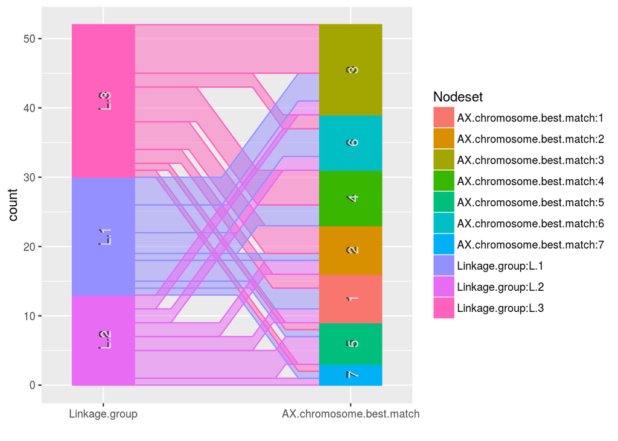

```r
lgpax <- read.table("external_QC_raw/PaxChr.csv", header=T, sep = ",")
ggparallel(list('Linkage.group', 'AX.chromosome.best.match'), lgpax)
```

## Compare with Optical mapping Super Scaffolds (OMss)

Are the same contigs together on a chromosome and on a super-scaffold?

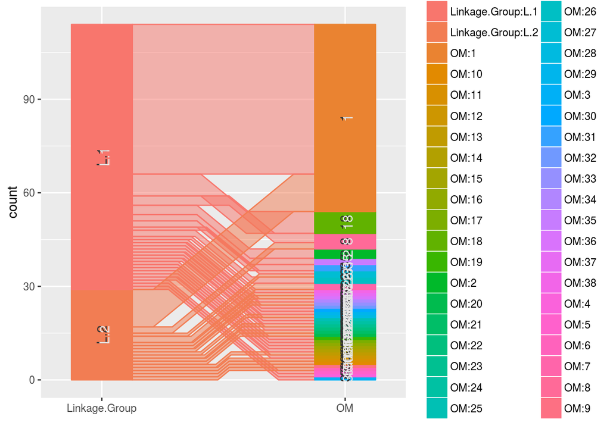

```r
ss <- read.table("external_QC_raw/OMss.csv", sep=",", header=T)
ss[,"OM"] <- as.numeric(as.factor(ss$Super.Scaffold.OM))
ggparallel(list('Linkage.Group','OM'), ss)
```

Check if the “problematic” contigs (the ones occurring in more than 1 linkage group) show conflicts in the optical mapping. There are 242 contigs showing conflict and 178 inter-LG-duplicate contigs. Find list of conflicting Contigs in Optical mapping ouput and compare to the duplicate contigs list. 36 of the 178 (20%) duplicate (among LGs) contigs are also conflicting in the optical mapping.

```bash
# temp.txt contains the contig names from the file find_conflicting_contigs_OM.txt (generated by the script find_conflicting_contigs_OM.sh)
grep -f temp.txt duplicate_ctgs.txt
```

## Compare with P.axillaris caps markers (caps)

Caps markers are markers which have been associated with a chromosome. Align caps to NGS genome and check which Contigs are listed there.

Made database of P.exserta genome for blastn with `makeblastdb -in P.EXSERTA.contigs.v1.1.3.fasta -dbtype nucl -parse_seqids`. Copy sequence and name of marker into file query.fasta and then blast with `blastn -db P.EXSERTA.contigs.v1.1.3.fasta -query query.fasta -out results.out`. Grep “Ctg” in the results file with `grep Ctg results.out` and search the Ctg names in the genetic map linkage groups.

```r
#write.cross(map1, format="qtab") # and only use data_location.qtab for searching Ctg names.
```

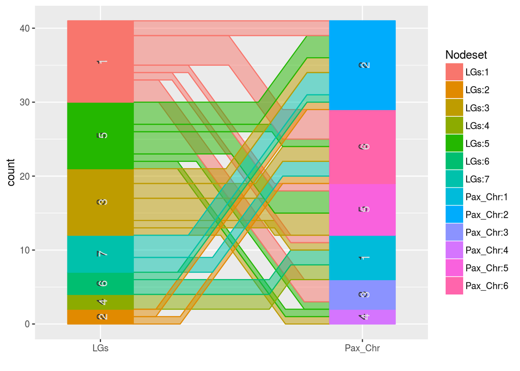

```r
caps <- read.table("external_QC_raw/caps.csv", sep="\t", header=F)
caps <- cbind(caps, as.numeric(substring(as.character(caps$V4), first=3)))
names(caps)[6] <- "LGs"
names(caps)[1] <- "Pax_Chr"
ggparallel(list('LGs','Pax_Chr'), caps, sub="chr7 absent")
```

Caps markers could not help to identify which LG is which chromosome. Either the Axillaris assembly or the genetic map is full of errors.

## unique contigs

```r
names <- read.csv("external_QC_raw/ctgnames.csv", header=T)
l1c <- unique(names[which(names[,1] == "L.1"),4])
l2c<- unique(names[which(names[,1] == "L.2"),4])
l3c<- unique(names[which(names[,1] == "L.3"),4])
l4c<- unique(names[which(names[,1] == "L.4"),4])


l1c[which(l1c %in% l2c)]
```

```
## [1] Peex113Ctg17958 Peex113Ctg17609 Peex113Ctg00825
## 225 Levels: Peex113Ctg00043 Peex113Ctg00050 ... Peex113Ctg18704
```

```r
venn.diagram(
x = list(l1c , l2c , l3c),
category.names = c("L.1" , "L.2 " , "L.3"),
filename = '#shared_contigs_among_LGs.png', output = T , imagetype="png" , height = 480 ,   width = 480 ,  resolution = 300,  compression = "lzw", lwd = 2, lty = 'blank', fill = c('yellow', 'purple', 'green'), cex = 1, fontface = "bold", fontfamily = "sans", cat.cex = 0.6, cat.fontface = "bold", cat.default.pos = "outer", cat.pos = c(-27, 27, 135), cat.dist = c(0.055, 0.055, 0.085), cat.fontfamily = "sans", rotation = 1)
```

```
## [1] 1
```

## Finding sequence length covered by genetic map

From ctgslen_names, the contig names which are unique can be taken and searched in the fasta.fai file. The second column indicates contig length in a fasta.fai file.

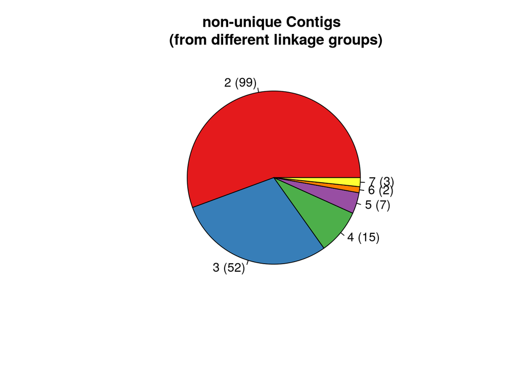

```r
# getting some information about unique contigs from newest genetic map
ctgs <- read.table("output_map/ctglist.txt", header=T)

# read out the duplicated contigs and the amount of time they occurr in linkage groups
# ctgsl : list of name of contig and where it occurs (in which linkage group)
# ctgslen : amount of contigs from different linkage groups per marker
# ctgslen_names : names of the given contigs from vector above
# counter : number of markers with contig uniquely from one linkage group
ctgsl <- list() ; counter = 0 ; ctgslen <- c() ; ctgslen_names <- c() ; toiter <- unique(ctgs$marker_name)
for(i in 1:length(toiter)){
  n <- as.vector(ctgs[which(grepl(toiter[i], ctgs$marker_name)),2])
  if(length(unique(n)) > 1){
    ctgsl[[as.character(unique(toiter)[i])]] <- unique(n)
    ctgslen<- c(ctgslen, length(unique(n)))
    ctgslen_names <- c(ctgslen_names, as.character(unique(toiter)[i]))
  } else {
    counter = counter + 1
  }
}
rm(toiter); rm(counter)


#total number of unique contigs
# length(unique(ctgs$marker_name)) # 590
# 412 unique contigs + 178 contigs occurring more than once
# length(ctgsl) # 178
# ctgslen_names holds the names of the non-unique contigs

labs = paste(as.character(as.data.frame(table(ctgslen))[,1]), " (", as.data.frame(table(ctgslen))[,2], ")", sep="")
# pdf("output_map/pie_non-unique-contigs.pdf")
pie(as.data.frame(table(ctgslen))$Freq, labels = labs,
    main=paste("non-unique Contigs", "\n", "(from different linkage groups)"), col = brewer.pal(6, "Set1"))
```

```r
# dev.off()

write(ctgslen_names, "stats_overviews/unique_ctg_names.txt", sep="\n")
write(as.character(ctgs[,1]), "names.txt", sep = "\n")
```

Finding length of contigs and sum. If a file names.txt contaings the unique contig names as list of names separated by “”, it can be searched in the fasta.fai file. Both files must be placed in the same directory or in GBS_LepMap3 as indicated by the code.

```bash
grep -f /home/exserta/Documents/master_project_noelle/projects/BioNano-exserta/GBS_LepMAP3/names.txt a_P.EXSERTA.contigs.v1.1.3.fasta.fai | awk '{SUM += $2} END {print SUM}'
cat a_P.EXSERTA.contigs.v1.1.3.fasta.fai | awk '{SUM += $2} END {print SUM}'
```

```
## grep: a_P.EXSERTA.contigs.v1.1.3.fasta.fai: No such file or directory
##
## cat: a_P.EXSERTA.contigs.v1.1.3.fasta.fai: No such file or directory
```

```r
# bases <- 361817069
# bases / 1000000000 # 361.8 megabases are covered by the map. (= 0.362 Gbp)
# totbases <- 1544969282 ; totbases / 1000000000 # 1.545 Gbp in the exserta assembly.
# bp_per_LG <- matrix(data = NA, nrow = 9, ncol = 3)
# colnames(bp_per_LG) <- c("LG", "bp", "Mbp")
# x <- 8248668
# bp_per_LG[8,] <- c("L.8", x, x/1000000)
# bp_per_LG
# saveRDS(bp_per_LG, file="bp_per_LG")
readRDS("bp_per_LG")
```

[output not shown]

### how long are the duplicate contigs?

If the duplicate contigs are the longest ones, a misassembly is more probable. At the same time, it is more likely to have more than one marker per contig if it is longer.

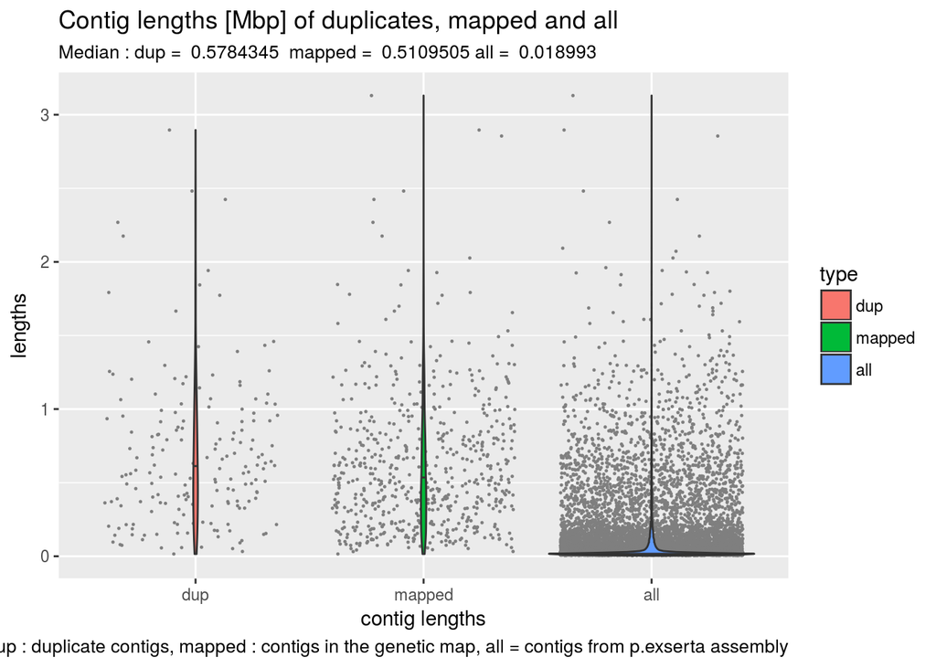

```r
# c_bp <- read.table("delete/test.txt") # the duplicate contigs
# all_bp <- read.table("delete/test2.txt")
# map_bp <- read.table("delete/test3.txt")
# d <- rbind(cbind(c_bp, "type" = "dup"),  cbind(map_bp, "type" = "mapped"), cbind( all_bp, "type" = "all"))
# colnames(d)[1] <- "len_bp"
# d$V1 <- d$len_bp / 1000000
# saveRDS(d, "external_QC_raw/contig_lens_violin")
d <- readRDS("external_QC_raw/contig_lens_violin")
ggplot(d, aes(factor(type), V1)) +
  geom_jitter(height = 0, colour = "grey50", size=0.2) + geom_violin(aes(fill = type), draw_quantiles = 0.5) + labs(x = "contig lengths", y="lengths", title = "Contig lengths [Mbp] of duplicates, mapped and all", subtitle = paste("Median : dup = ", median(d[d$type == "dup", "V1"]), " mapped = ", median(d[d$type == "mapped", "V1"]), "all = ", median(d[d$type == "all", "V1"])) , caption = "dup : duplicate contigs, mapped : contigs in the genetic map, all = contigs from p.exserta assembly")
```

```r
# ggsave("external_QC_raw/contig_lengths.pdf")
```

It seems like the contig length does not differ among duplicate contigs and all contigs in the map. Neither is there a very long contig influencing the median a lot, as can be observed by the point height in the plot (and second, because median is not impacted much by an outlier). Note : when comparing points, the x axis value within a gropu has no influence (only graphical purposes) so only the y axis shows length of the given contig.

# read the sequences of the markers

For each marker, copy out some sequence information.

# Outlook

Further process the file with [ALLMAPS](https://github.com/tanghaibao/jcvi/wiki/ALLMAPS%3A-How-to-use-different-types-of-genomic-maps)